Homework 1

Berke Aktürk - 2018402192 - IE360 - Spring 2022  
12.04.2022

# Data Visualization & Google Trends on Different Measures from Turkey

# Introduction

In this assignment, three different data measures from the EVDS system and two different related 'keywords' from Google Trends are selected to investigate the relationships among them. The three data measures from EVDS are monthly exchange rates from 2014 to the end of 2021, the monthly house price index from 2014 to the end of 2021, and the car price index from 2014 to the end of 2021. The representative keywords from Google Trends are the volume of price increase searches(zam) and the volume of inflation(enflasyon) searches on Google. To discover the underlying relationships and correlations of these datasets, line plots, boxplots, bar plots, and correlation plots are used. Some of the questions intended to be answered are given below:

- Is there any relationship between exchange rates and house prices?
- Is there any relationship between exchange rates and car prices?
- Is the behavior of the change in the car prices similar to the change in the house prices?
- Do the changes in exchange rates, car prices and house prices have an impact on what people search on Google?
- Can we observe this impact stated above on the keywords 'zam'(price increase) and 'enflasyon'(inflation)?

### Importing Required Libraries

```r
library(zoo)
library(lubridate)
library(openxlsx)
library(ggplot2)
library(data.table)
library(ggcorrplot)
```

### Exchange Rates

```r
exchange_df = read.xlsx('C:\\Users\\berke\\Downloads\\IE360files\\dollar_try_exc.xlsx')
exchange_df$Tarih = as.Date(as.yearmon(exchange_df$Tarih))
exchange_df$Month = month(exchange_df$Tarih)
str(exchange_df)
summary(exchange_df)
```

```
'data.frame':	96 obs. of  3 variables:
 $ Tarih       : Date, format: "2014-01-01" "2014-02-01" ...
 $ exchangerate: num  2.22 2.21 2.22 2.13 2.09 ...
 $ Month       : int  1 2 3 4 5 6 7 8 9 10 ...
```

```
     Tarih             exchangerate        Month
 Min.   :2014-01-01   Min.   : 2.089   Min.   : 1.00
 1st Qu.:2015-12-24   1st Qu.: 2.915   1st Qu.: 3.75
 Median :2017-12-16   Median : 3.810   Median : 6.50
 Mean   :2017-12-15   Mean   : 4.734   Mean   : 6.50
 3rd Qu.:2019-12-08   3rd Qu.: 6.041   3rd Qu.: 9.25
 Max.   :2021-12-01   Max.   :13.519   Max.   :12.00
```

### House Prices

```r
housingpi_df = read.xlsx('C:\\Users\\berke\\Downloads\\IE360files\\housing price index.xlsx')
housingpi_df$Tarih = as.Date(as.yearmon(housingpi_df$Tarih))
housingpi_df$Month = month(housingpi_df$Tarih)
str(housingpi_df)
summary(housingpi_df)
```

```
'data.frame':	96 obs. of  3 variables:
 $ Tarih              : Date, format: "2014-01-01" "2014-02-01" ...
 $ Housing.Price.Index: num  64.1 64.8 65.7 66.8 67.5 68.2 69.3 70.2 70.9 71.5 ...
 $ Month              : int  1 2 3 4 5 6 7 8 9 10 ...
```

```
     Tarih            Housing.Price.Index     Month
 Min.   :2014-01-01   Min.   : 64.1       Min.   : 1.00
 1st Qu.:2015-12-24   1st Qu.: 85.4       1st Qu.: 3.75
 Median :2017-12-16   Median :103.8       Median : 6.50
 Mean   :2017-12-15   Mean   :110.9       Mean   : 6.50
 3rd Qu.:2019-12-08   3rd Qu.:119.3       3rd Qu.: 9.25
 Max.   :2021-12-01   Max.   :247.4       Max.   :12.00
```

### Car Prices

```r
carpi_df = read.xlsx('C:\\Users\\berke\\Downloads\\IE360files\\car price index.xlsx')
carpi_df$Tarih = as.Date(as.yearmon(carpi_df$Tarih))
carpi_df$Month = month(carpi_df$Tarih)
str(carpi_df)
summary(carpi_df)
```

```
'data.frame':	96 obs. of  3 variables:
 $ Tarih     : Date, format: "2014-01-01" "2014-02-01" ...
 $ Car_prices: num  152 161 167 168 167 ...
 $ Month     : int  1 2 3 4 5 6 7 8 9 10 ...
```

```
     Tarih              Car_prices        Month
 Min.   :2014-01-01   Min.   :151.7   Min.   : 1.00
 1st Qu.:2015-12-24   1st Qu.:188.4   1st Qu.: 3.75
 Median :2017-12-16   Median :267.1   Median : 6.50
 Mean   :2017-12-15   Mean   :296.7   Mean   : 6.50
 3rd Qu.:2019-12-08   3rd Qu.:358.4   3rd Qu.: 9.25
 Max.   :2021-12-01   Max.   :786.0   Max.   :12.00
```

Data Visualizations

## Dollar Exchange Rate Plots

### Lineplot For USD/TRY Exchange Rates

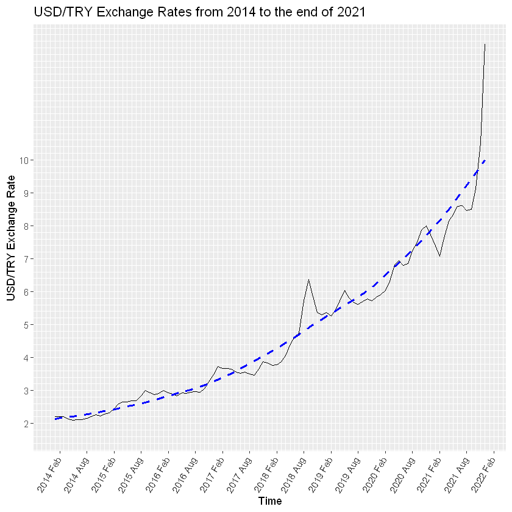

```r
ggplot(exchange_df,aes(x=Tarih,y=exchangerate)) + geom_line(color = 'black') +
    geom_smooth(color='blue',linetype='dashed',size=1,fill=NA) +
    labs(title = 'USD/TRY Exchange Rates from 2014 to the end of 2021', x = 'Time', y = 'USD/TRY Exchange Rate') +
    scale_x_date(date_breaks = '6 month', date_labels = '%Y %b', date_minor_breaks = '1 month' ) +
    scale_y_continuous(breaks = seq(from = 0, to = 10, by = 1),
                      minor_breaks = seq(from=0,to = 16, by = .2))  +
    theme(axis.text.x=element_text(angle=60, hjust=1.4, vjust = 1.4))
```

### Barplot For USD/TRY Exchange Rates

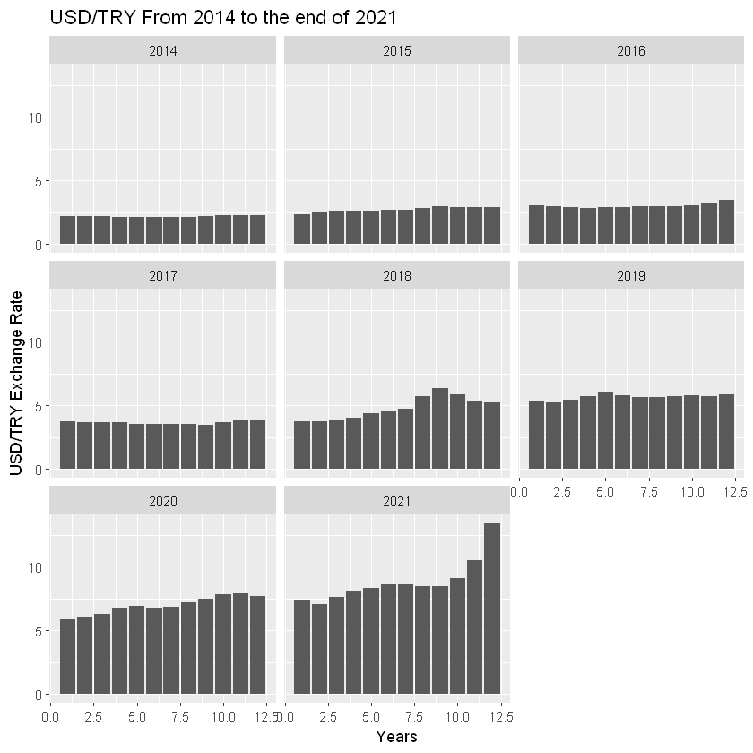

```r
ggplot(exchange_df,aes(x=Month,y=exchangerate)) + geom_bar(stat='identity') + facet_wrap(~year(Tarih)) +
xlab('Years') + ylab('USD/TRY Exchange Rate') + ggtitle('USD/TRY From 2014 to the end of 2021')
```

### Boxplot For USD/TRY Exchange Rates

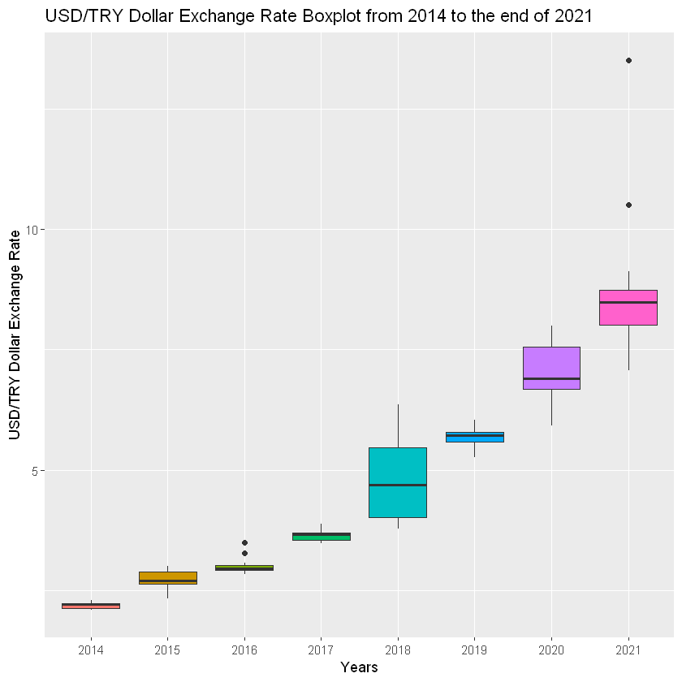

```r
ggplot(exchange_df,aes(x=factor(year(Tarih)),y=exchangerate)) + geom_boxplot(aes(fill=factor(year(Tarih))))+
       xlab('Years') +
       ylab('USD/TRY Dollar Exchange Rate') +
       ggtitle('USD/TRY Dollar Exchange Rate Boxplot from 2014 to the end of 2021') +
       theme(legend.position = 'None')
```

When the yearly changes in the USD/TRY Exchange rates are taken into consideration, it can be seen that there is an exponential growth in USD/TRY exchange rates. There is a slow-growing behavior in the data between 2014 and 2018. After 2018, the increase rate demonstrates a significant increase. Significant jumps in the USD/TRY exchange rates can be observed in the middle of 2018, and the last period of 2021. In 2018, there is a nearly constant high-sloped increase in the USD/TRY exchange rates unlike in 2021 where the jumps are tremendous and considered as outliers by the boxplot.

# Housing Price Index Plots

### Lineplot For Housing Price Index

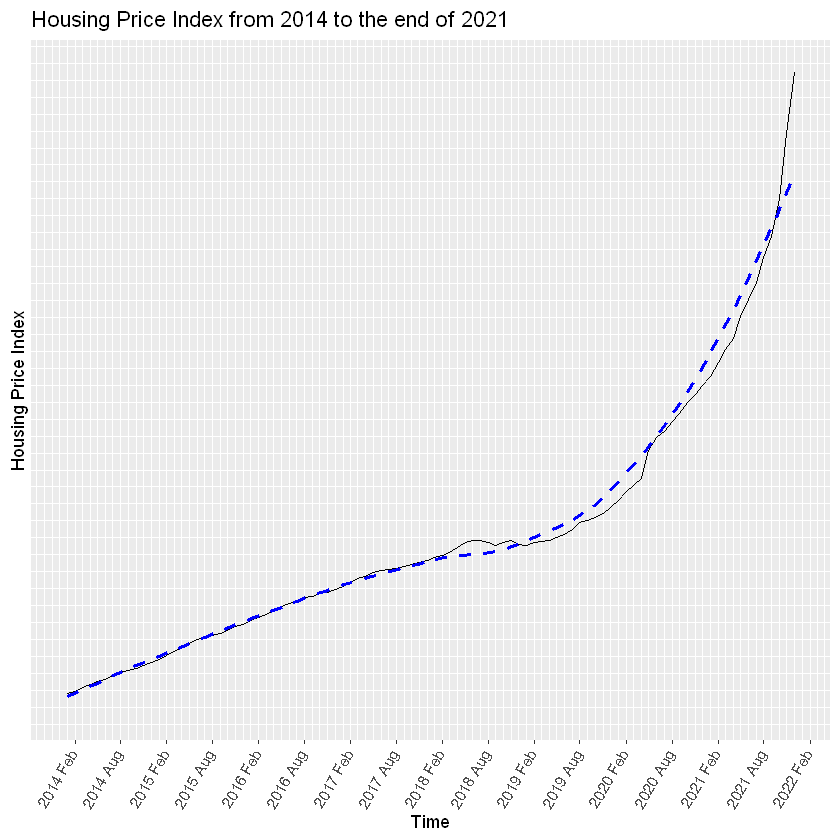

```r
ggplot(housingpi_df,aes(x=Tarih,y=Housing.Price.Index)) + geom_line(color = 'black') +
    geom_smooth(color='blue',linetype='dashed',size=1,fill=NA) +
    labs(title = 'Housing Price Index from 2014 to the end of 2021', x = 'Time', y = 'Housing Price Index') +
    scale_x_date(date_breaks = '6 month', date_labels = '%Y %b', date_minor_breaks = '1 month' ) +
    scale_y_continuous(breaks = seq(from = 0, to = 10, by = 1),
                      minor_breaks = seq(from=0,to = 300, by = 5))  +
    theme(axis.text.x=element_text(angle=60, hjust=1.4, vjust = 1.4))
```

### Barplot For Housing Price Index

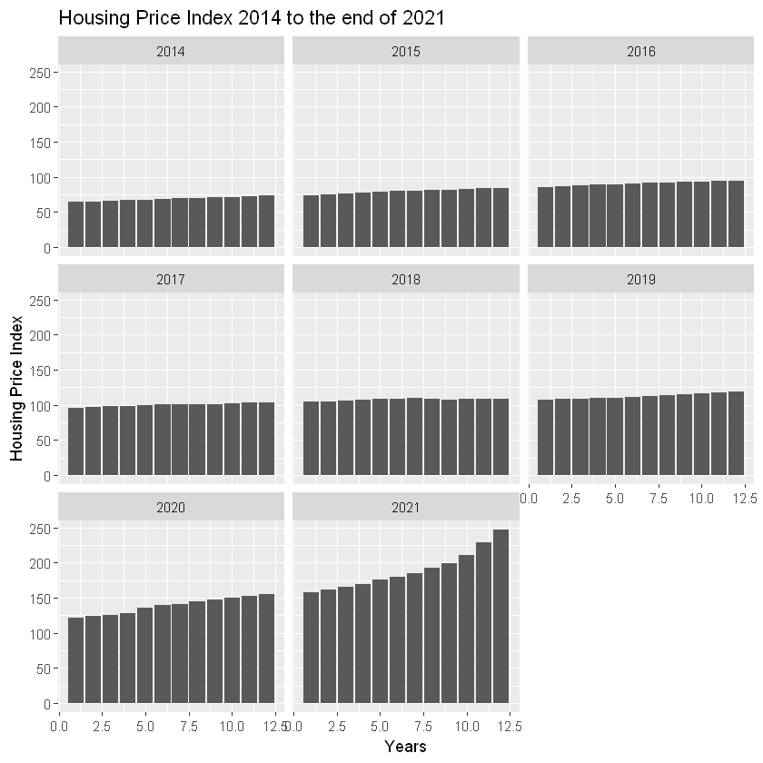

```r
ggplot(housingpi_df,aes(x=Month,y=Housing.Price.Index)) +
    geom_bar(stat='identity') +
    facet_wrap(~year(Tarih)) +
    xlab('Years') +
    ylab('Housing Price Index') +
    ggtitle('Housing Price Index 2014 to the end of 2021')
```

### Boxplot For Housing Price Index

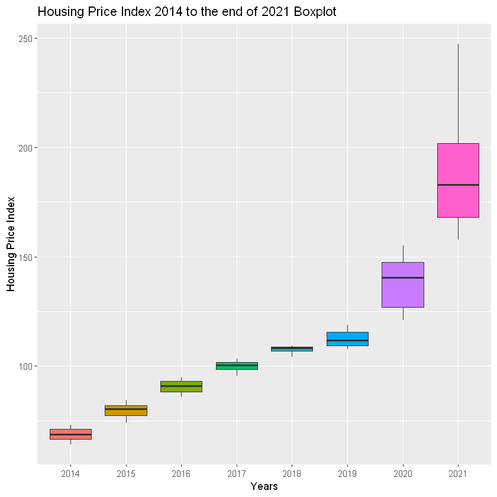

```r
ggplot(housingpi_df,aes(x=factor(year(Tarih)),y=Housing.Price.Index)) + geom_boxplot(aes(fill=factor(year(Tarih))))+
       xlab('Years') +
       ylab('Housing Price Index') +
       ggtitle('Housing Price Index 2014 to the end of 2021 Boxplot') +
       theme(legend.position = 'None')
```

The housing price index vs. Time graph also demonstrates an exponential increase behavior over time. Until 2020, there is almost a steady increase in the graph. However, after 2020 increase rate starts to grow significantly. A reason for this situation might be the effect of the USD/TRY Exchange Rate. The effect of the change in the USD/TRY exchange rates does not have an imminent effect on the house prices, however in time, the prices of the houses become relatively cheaper against the other currencies, it might be tempting to buy a house for foreigners. As a result, the demand for house increases, and the price of the houses increase correspondingly. Furthermore, the worried Turkish citizens might have wanted to invest their money in immovable properties to avoid the decrease in the value of the Turkish currency. As a result, the demand increases again and therefore the prices increase.

# Car Price Index Plots

### Lineplot For Car Price Index

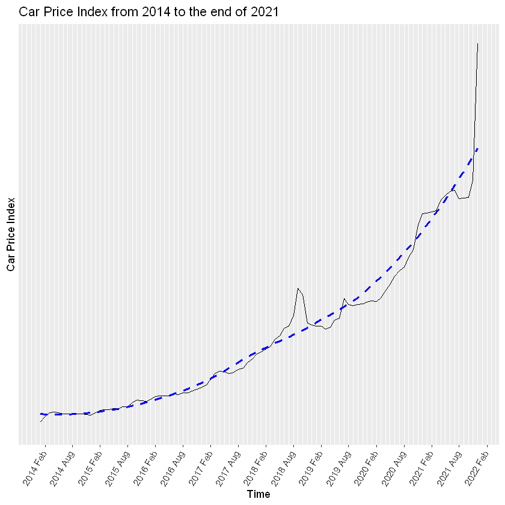

```r
ggplot(carpi_df,aes(x=Tarih,y=Car_prices)) + geom_line(color = 'black') +
    geom_smooth(color='blue',linetype='dashed',size=1,fill=NA) +
    labs(title = 'Car Price Index from 2014 to the end of 2021', x = 'Time', y = 'Car Price Index') +
    scale_x_date(date_breaks = '6 month', date_labels = '%Y %b', date_minor_breaks = '1 month' ) +
    scale_y_continuous(breaks = seq(from = 0, to = 10, by = 1),
                      minor_breaks = seq(from=0,to = 20, by = .5))  +
    theme(axis.text.x=element_text(angle=60, hjust=1.4, vjust = 1.4))
```

### Barplot For Car Price Index

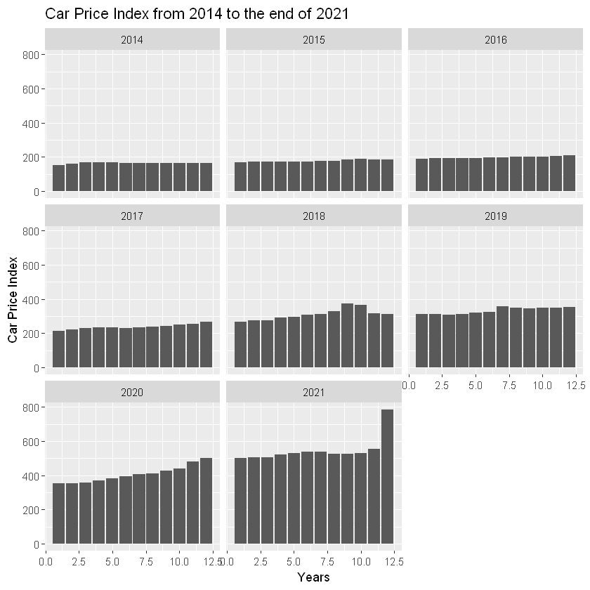

```r
ggplot(carpi_df,aes(x=Month,y=Car_prices)) +
    geom_bar(stat='identity') +
    facet_wrap(~year(Tarih)) +
    xlab('Years') +
    ylab('Car Price Index') +
    ggtitle('Car Price Index from 2014 to the end of 2021')
```

### Boxplot For Car Price Index

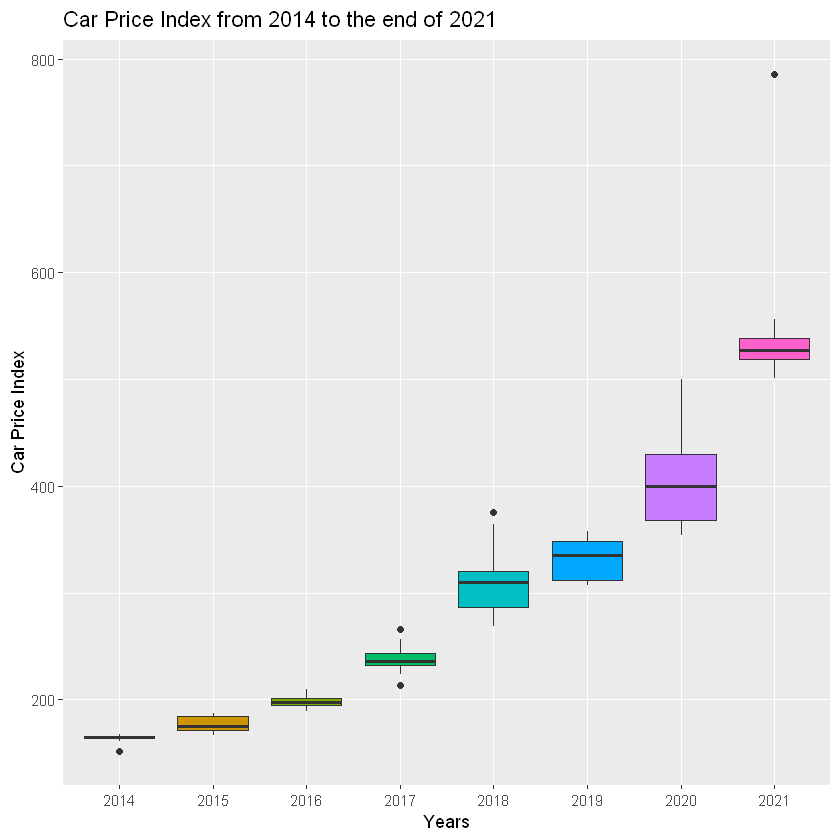

```r
ggplot(carpi_df,aes(x=factor(year(Tarih)),y=Car_prices)) + geom_boxplot(aes(fill=factor(year(Tarih))))+
       xlab('Years') +
       ylab('Car Price Index') +
       ggtitle('Car Price Index from 2014 to the end of 2021') +
       theme(legend.position = 'None')
```

Similar to the housing price index graph, the car price index graph demonstrates an exponential growing behavior. As the USD/TRY increases, the price of cars increases since their subcomponents are not produced in Turkey. The subcomponents of the cars are imported from abroad, and therefore their prices are generally based on dollars, which gains value constantly against TRY. Another reason which impacts the car prices might be the occurrence of the pandemic since the people who want to avoid the virus tend to buy their personal cars to protect themselves. This situation causes a significant demand for the cars which impacts the price of the cars correspondingly.

# Google Trends Data

The choosen 'keywords' to observe the changes in the data above are 'zam'(Price increase) and 'enflasyon'(inflation) searches on Google.

## Price Increase('Zam') Data

'Zam' keyword is choosen to observe the changes in the data above. Since the increase in USD/TRY exchange rates will cause an increase in almost every goods sold in Turkey. For instance, the price of every basic product in markets will increase. Moreover, The cost of electricity, natural gas, and water will increase and Turkish people tend to express this situation by calling 'Zam'. Moreover, the increase in the house prices and car prices might cause people to search 'Zam' keyword on the Google as well.

```r
price_increase_df = read.csv('C:\\Users\\berke\\Downloads\\IE360files\\zam.csv')
price_increase_df$Tarih = as.Date(as.yearmon(price_increase_df$Tarih))
price_increase_df$Month = month(price_increase_df$Tarih)
str(price_increase_df)
summary(price_increase_df)
```

```
'data.frame':	96 obs. of  3 variables:
 $ Tarih: Date, format: "2014-01-01" "2014-02-01" ...
 $ zam  : int  14 6 4 6 4 6 7 4 10 15 ...
 $ Month: int  1 2 3 4 5 6 7 8 9 10 ...
```

```
     Tarih                 zam             Month
 Min.   :2014-01-01   Min.   :  3.00   Min.   : 1.00
 1st Qu.:2015-12-24   1st Qu.:  7.00   1st Qu.: 3.75
 Median :2017-12-16   Median : 10.00   Median : 6.50
 Mean   :2017-12-15   Mean   : 13.47   Mean   : 6.50
 3rd Qu.:2019-12-08   3rd Qu.: 14.00   3rd Qu.: 9.25
 Max.   :2021-12-01   Max.   :100.00   Max.   :12.00
```

### Lineplot for Volume of Price Increase('Zam') Searches

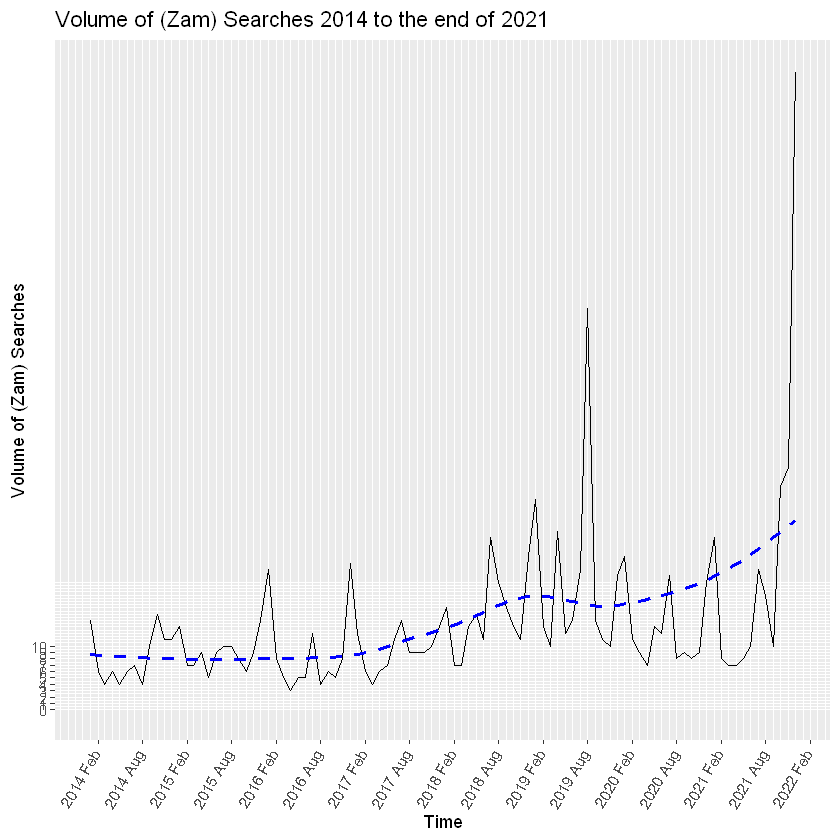

```r
ggplot(price_increase_df,aes(x=Tarih,y=zam)) + geom_line(color = 'black') +
    geom_smooth(color='blue',linetype='dashed',size=1,fill=NA) +
    labs(title = 'Volume of (Zam) Searches 2014 to the end of 2021', x = 'Time', y = 'Volume of (Zam) Searches') +
    scale_x_date(date_breaks = '6 month', date_labels = '%Y %b', date_minor_breaks = '1 month' ) +
    scale_y_continuous(breaks = seq(from = 0, to = 10, by = 1),
                      minor_breaks = seq(from=0,to = 20, by = .5))  +
    theme(axis.text.x=element_text(angle=60, hjust=1.4, vjust = 1.4))
```

### Barplot for Volume of Price Increase('Zam') Searches

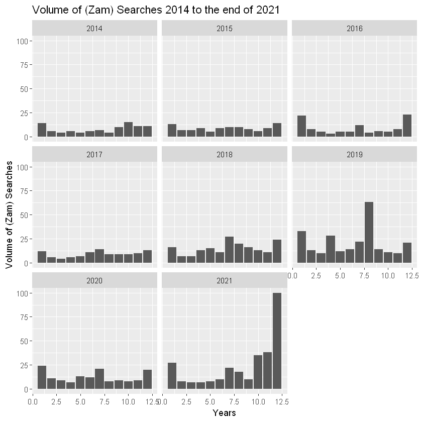

```r
ggplot(price_increase_df,aes(x=Month,y=zam)) +
    geom_bar(stat='identity') +
    facet_wrap(~year(Tarih)) +
    xlab('Years') +
    ylab('Volume of (Zam) Searches') +
    ggtitle('Volume of (Zam) Searches 2014 to the end of 2021')
```

### Boxplot for Volume of Price Increase('Zam') Searches

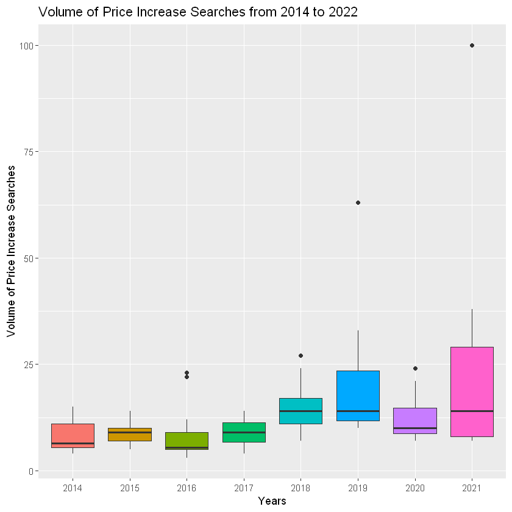

```r
ggplot(price_increase_df,aes(x=factor(year(Tarih)),y=zam)) + geom_boxplot(aes(fill=factor(year(Tarih))))+
       xlab('Years') +
       ylab('Volume of Price Increase Searches') +
       ggtitle('Volume of Price Increase Searches from 2014 to 2022') +
       theme(legend.position = 'None')
```

When the graphs above are investigated, it can be seen that the behavior of the search volume of 'zam' demonstrates an increasing but dynamic behavior. There are significant fluctuations in the data from month to month as expected. Since the keyword, 'zam' is also relevant to the increase in the salary of the people, which might be influenced by the explanations from the governmental institutions. However, when the overall plots are investigated, it can be seen that the increase in the USD/TRY exchange rates causes an increase in the goods needed for people and the price of those goods increases. Therefore, the search volume of the keyword 'zam' has an increasing trend over time. Moreover, the search volume shows a significant increase starting from 2018 similar to the exchange rates, house prices, and car prices. We can observe a reasonable correlation between these three measures and the search volume of the keyword 'zam'.

# Inflation Searches Data

```r
inflation_search_df = read.csv('C:\\Users\\berke\\Downloads\\IE360files\\inflation.csv')
inflation_search_df$Tarih = as.Date(as.yearmon(inflation_search_df$Tarih))
inflation_search_df$Month = month(inflation_search_df$Tarih)
str(inflation_search_df)
summary(inflation_search_df)
```

```
'data.frame':	96 obs. of  3 variables:
 $ Tarih    : Date, format: "2014-01-01" "2014-02-01" ...
 $ Inflation: int  16 7 7 7 8 7 8 6 6 6 ...
 $ Month    : int  1 2 3 4 5 6 7 8 9 10 ...
```

```
     Tarih              Inflation          Month
 Min.   :2014-01-01   Min.   :  6.00   Min.   : 1.00
 1st Qu.:2015-12-24   1st Qu.:  9.00   1st Qu.: 3.75
 Median :2017-12-16   Median : 15.00   Median : 6.50
 Mean   :2017-12-15   Mean   : 21.34   Mean   : 6.50
 3rd Qu.:2019-12-08   3rd Qu.: 28.00   3rd Qu.: 9.25
 Max.   :2021-12-01   Max.   :100.00   Max.   :12.00
```

### Lineplot for Volume of Inflation ('Enflasyon') Searches

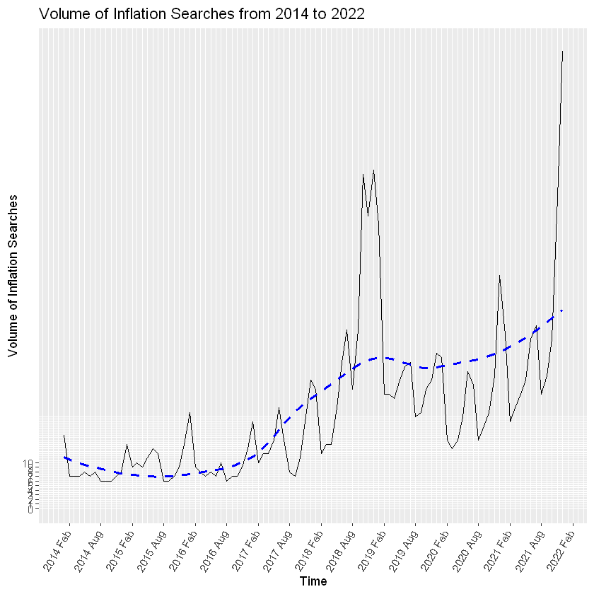

```r
ggplot(inflation_search_df,aes(x=Tarih,y=Inflation)) + geom_line(color = 'black') +
    geom_smooth(color='blue',linetype='dashed',size=1,fill=NA) +
    labs(title = 'Volume of Inflation Searches from 2014 to 2022', x = 'Time', y = 'Volume of Inflation Searches') +
    scale_x_date(date_breaks = '6 month', date_labels = '%Y %b', date_minor_breaks = '1 month' ) +
    scale_y_continuous(breaks = seq(from = 0, to = 10, by = 1),
                      minor_breaks = seq(from=0,to = 20, by = .5))  +
    theme(axis.text.x=element_text(angle=60, hjust=1.4, vjust = 1.4))
```

### Barplot for Volume of Inflation ('Enflasyon') Searches

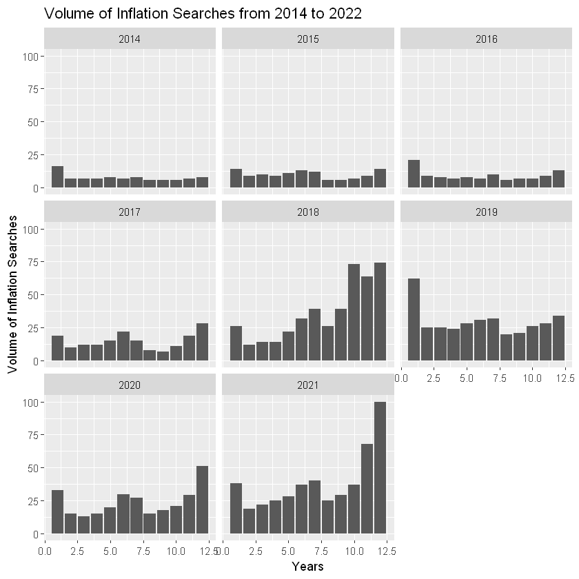

```r
ggplot(inflation_search_df,aes(x=Month,y=Inflation)) +
    geom_bar(stat='identity') +
    facet_wrap(~year(Tarih)) +
    xlab('Years') +
    ylab('Volume of Inflation Searches') +
    ggtitle('Volume of Inflation Searches from 2014 to 2022')
```